# Visualizing Text and Distributions

# Data Visualization Project 03

In this exercise you will explore methods to visualize text data and practice how to recreate charts that show the distributions of a continuous variable.

## Part 1: Density Plots

Using the dataset obtained from FSU’s [Florida Climate Center](https://climatecenter.fsu.edu/climate-data-access-tools/downloadable-data), for a station at Tampa International Airport (TPA) from 2016 to 2017, attempt to recreate the charts shown below

```r
library(ggridges)
```

```r
library(tidyverse)
library(ggplot2)
library(lubridate)
weather_tpa <- read_csv("https://github.com/reisanar/datasets/raw/master/tpa_weather_16_17.csv")
# random sample
sample_n(weather_tpa, 4)
```

```
## # A tibble: 4 × 6
##    year month   day precipitation max_temp min_temp
##   <dbl> <dbl> <dbl>         <dbl>    <dbl>    <dbl>
## 1  2016     5    15          0          88       67
## 2  2016     3    25          0.72       76       63
## 3  2016     1    12          0          67       45
## 4  2016     3    16          0          81       71
```

See https://www.reisanar.com/slides/relationships-models#10 for a reminder on how to use this dataset with the `lubridate` package for dates and times.

1. Recreate the plot below:

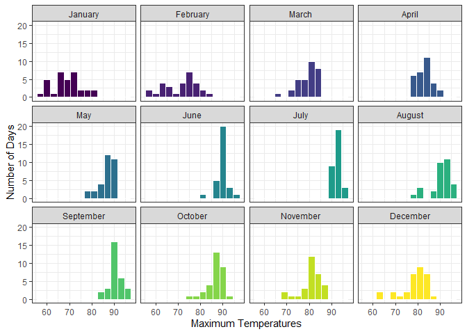

```r
library(ggridges)
library(ggplot2)
library(viridis)
library(tidyverse)
library(forcats)
library(viridisLite)
library(lubridate)

tpa_clean <- weather_tpa %>%
  unite("doy", year, month, day, sep = "-") %>%
  mutate(doy = ymd(doy),
         max_temp = as.double(max_temp),
         min_temp = as.double(min_temp),
         precipitation = as.double(precipitation))
ggplot(data = weather_tpa)+
  geom_histogram(aes(x= max_temp,fill = as.factor(month)),binwidth = 3, color = "white")+
  theme_bw()+
  scale_fill_viridis(discrete = TRUE)+
  facet_wrap(~fct_reorder(month.name[month], month)) +
  theme(legend.position = "none") +
  labs(x = "Maximum Temperatures", y = "Number of Days")
```

Hint: the option `binwidth = 3` was used with the `geom_histogram()` function.

2. Recreate the plot below:

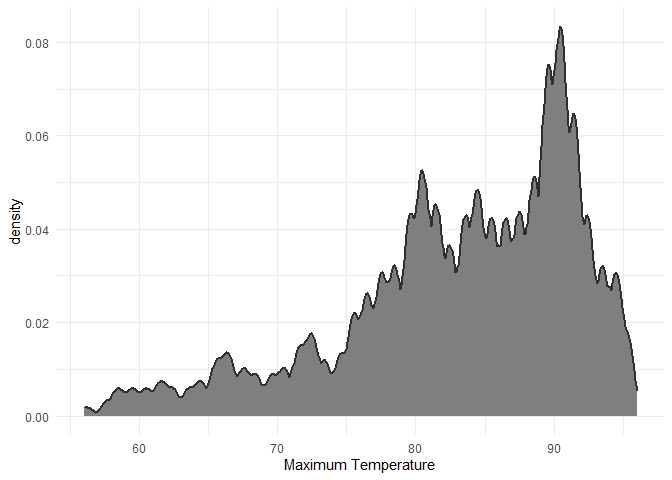

```r
plot_2<-ggplot(data = weather_tpa) +
  geom_density(aes(max_temp),bw = .5, kernel = "epanechnikov",
               color = "#2f2f2f", fill = "#7f7f7f",
               size = 1) +
  theme_minimal() +labs(x = "Maximum Temperature")
plot_2
```

Hint: check the `kernel` parameter of the `geom_density()` function, and use `bw = 0.5`.

3. Recreate the chart below:

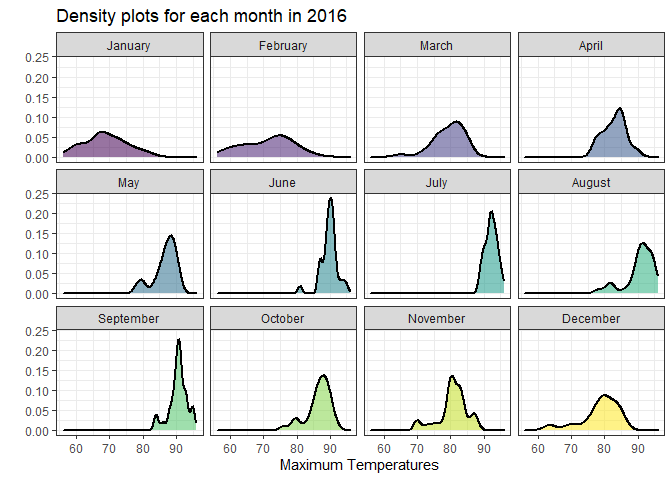

```r
plot_3<-ggplot(data = weather_tpa, aes(x = max_temp, fill = as.factor(month), alpha = 0.2)) +
  geom_density(size = 1) + theme_bw() + scale_fill_viridis_d() +
  facet_wrap(~fct_reorder(month.name[month], month)) +
  theme(legend.position = "none") +
  labs(x = "Maximum Temperatures", y = " ", title = "Density plots for each month in 2016")
plot_3
```

Hint: default options for `geom_density()` were used.

4. Recreate the chart below:

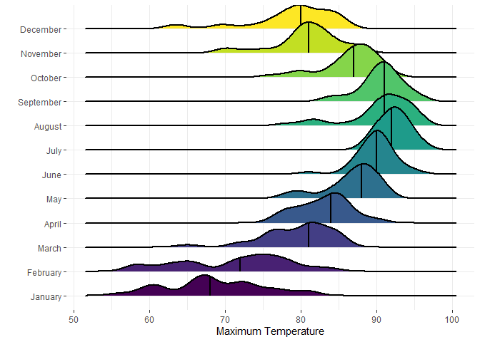

```r
plot_4<-ggplot(weather_tpa, aes(x = max_temp, y = fct_reorder(month.name[month], month), fill = as.factor(month))) +
  geom_density_ridges(bandwidth= 1.49, quantile_lines = TRUE, quantiles = 2, size = 1) +
  theme_bw() + scale_fill_viridis_d() +
  theme(legend.position = "none", panel.border = element_blank()) +
  labs(x = "Maximum Temperature", y = "")
plot_4
```

5. Recreate the plot below:

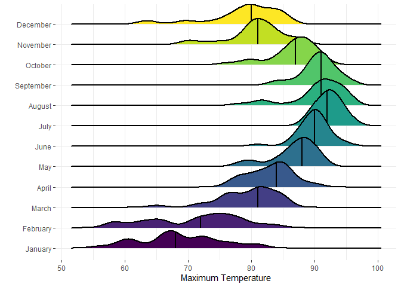

```r
plot_5<-ggplot(weather_tpa, aes(x = max_temp, y = fct_reorder(month.name[month], month), fill = as.factor(month))) +
  geom_density_ridges(bandwidth= 1.49, quantile_lines = TRUE, quantiles = 2, size = 1) +
  theme_bw() + scale_fill_viridis_d() +
  theme(legend.position = "none", panel.border = element_blank()) +
  labs(x = "Maximum Temperature", y = "")
plot_5
```

Hint: use the`ggridges` package, and the `geom_density_ridges()` function paying close attention to the `quantile_lines` and `quantiles` parameters.

6. Recreate the chart below:

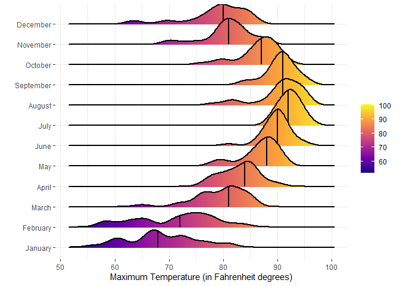

```r
options(warn = -1)
plot_6<-ggplot(weather_tpa, aes(x = max_temp, y = fct_reorder(month.name[month], month), fill = stat(x))) +
  geom_density_ridges_gradient(bandwidth= 1.49, quantile_lines = TRUE, quantiles = 2, size = 1) +
  theme_bw() + scale_fill_viridis_c(option = "plasma") +
  theme(panel.border = element_blank()) +
  labs(x = "Maximum Temperature (in Fahrenheit degrees)", y = "", fill = "")
plot_6
```

Hint: this uses the `plasma` option (color scale) for the *viridis* palette.

## Part 2: Visualizing Text Data

Review the set of slides (and additional resources linked in it) for visualizing text data: https://www.reisanar.com/slides/text-viz#1

Choose any dataset with text data, and create at least one visualization with it. For example, you can create a frequency count of most used bigrams, a sentiment analysis of the text data, a network visualization of terms commonly used together, and/or a visualization of a topic modeling approach to the problem of identifying words/documents associated to different topics in the text data you decide to use.

Make sure to include a copy of the dataset in the `data/` folder, and reference your sources if different from the ones listed below:

- [Billboard Top 100 Lyrics](https://github.com/reisanar/datasets/blob/master/BB_top100_2015.csv)

```r
library(tidytext)
bill_100 <- read_csv("https://raw.githubusercontent.com/reisanar/datasets/master/BB_top100_2015.csv")
board_100 <- bill_100%>%
  filter(Rank %in% 1:10) %>%
  unnest_tokens(word, Lyrics, token = "words") %>%
  filter(!word %in% stop_words$word, str_detect(word, "[a-z]"))
board_100
```

```
## # A tibble: 1,777 × 6
##     Rank Song        Artist                            Year Source word
##    <dbl> <chr>       <chr>                            <dbl>  <dbl> <chr>
##  1     1 uptown funk mark ronson featuring bruno mars  2015      1 hit
##  2     1 uptown funk mark ronson featuring bruno mars  2015      1 ice
##  3     1 uptown funk mark ronson featuring bruno mars  2015      1 cold
##  4     1 uptown funk mark ronson featuring bruno mars  2015      1 michelle
##  5     1 uptown funk mark ronson featuring bruno mars  2015      1 pfeiffer
##  6     1 uptown funk mark ronson featuring bruno mars  2015      1 white
##  7     1 uptown funk mark ronson featuring bruno mars  2015      1 gold
##  8     1 uptown funk mark ronson featuring bruno mars  2015      1 hood
##  9     1 uptown funk mark ronson featuring bruno mars  2015      1 girls
## 10     1 uptown funk mark ronson featuring bruno mars  2015      1 girls
## # … with 1,767 more rows
```

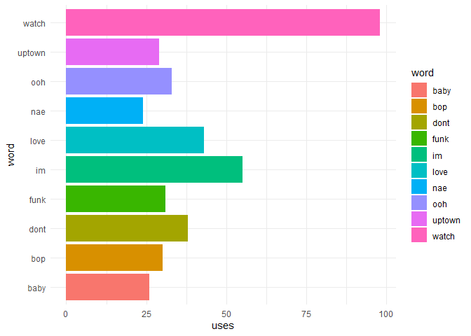

```r
word_viz <- board_100 %>%
  group_by(word) %>%
  summarise(uses=n()) %>%
  arrange(desc(uses)) %>%
  slice(1:10) %>%
  ggplot() +
  geom_bar(aes(x=word, y=uses, fill= word),
           stat = "identity") +
  coord_flip() +
  theme_minimal()
word_viz
```

```r
get_sentiments("bing")
```

```
## # A tibble: 6,786 × 2
##    word        sentiment
##    <chr>       <chr>
##  1 2-faces     negative
##  2 abnormal    negative
##  3 abolish     negative
##  4 abominable  negative
##  5 abominably  negative
##  6 abominate   negative
##  7 abomination negative
##  8 abort       negative
##  9 aborted     negative
## 10 aborts      negative
## # … with 6,776 more rows
```

```r
ed_sheeran<- bill_100 %>%
 filter(Artist == "ed sheeran") %>%
 unnest_tokens(word, Lyrics) %>%
 anti_join(stop_words)
head(ed_sheeran)
```

```
## # A tibble: 6 × 6
##    Rank Song              Artist      Year Source word
##   <dbl> <chr>             <chr>      <dbl>  <dbl> <chr>
## 1     2 thinking out loud ed sheeran  2015      1 legs
## 2     2 thinking out loud ed sheeran  2015      1 dont
## 3     2 thinking out loud ed sheeran  2015      1 sweep
## 4     2 thinking out loud ed sheeran  2015      1 feet
## 5     2 thinking out loud ed sheeran  2015      1 mouth
## 6     2 thinking out loud ed sheeran  2015      1 remember
```

```r
ed_sheeran %>%
  group_by(word) %>%
  summarise(uses = n()) %>%
  arrange(desc(uses))
```

```
## # A tibble: 213 × 2
##    word    uses
##    <chr>  <int>
##  1 love      20
##  2 dont      18
##  3 la        11
##  4 im         9
##  5 wanna      9
##  6 baby       8
##  7 heart      8
##  8 ck         7
##  9 loving     7
## 10 told       7
## # … with 203 more rows
```

```r
ed_sheeran
```

```
## # A tibble: 416 × 6
##     Rank Song              Artist      Year Source word
##    <dbl> <chr>             <chr>      <dbl>  <dbl> <chr>
##  1     2 thinking out loud ed sheeran  2015      1 legs
##  2     2 thinking out loud ed sheeran  2015      1 dont
##  3     2 thinking out loud ed sheeran  2015      1 sweep
##  4     2 thinking out loud ed sheeran  2015      1 feet
##  5     2 thinking out loud ed sheeran  2015      1 mouth
##  6     2 thinking out loud ed sheeran  2015      1 remember
##  7     2 thinking out loud ed sheeran  2015      1 taste
##  8     2 thinking out loud ed sheeran  2015      1 love
##  9     2 thinking out loud ed sheeran  2015      1 eyes
## 10     2 thinking out loud ed sheeran  2015      1 smile
## # … with 406 more rows
```

```r
top_5 <- read_csv("https://raw.githubusercontent.com/reisanar/datasets/master/BB_top100_2015.csv")
head(top_5, 10)
```

```
## # A tibble: 10 × 6
##     Rank Song              Artist                             Year Lyrics Source
##    <dbl> <chr>             <chr>                             <dbl> <chr>   <dbl>
##  1     1 uptown funk       mark ronson featuring bruno mars   2015 this …      1
##  2     2 thinking out loud ed sheeran                         2015 when …      1
##  3     3 see you again     wiz khalifa featuring charlie pu…  2015 its b…      1
##  4     4 trap queen        fetty wap                          2015 im li…      1
##  5     5 sugar             maroon 5                           2015 im hu…      1
##  6     6 shut up and dance walk the moon                      2015 oh do…      1
##  7     7 blank space       taylor swift                       2015 nice …      1
##  8     8 watch me          silento                            2015 now w…      1
##  9     9 earned it         the weeknd                         2015 you m…      1
## 10    10 the hills         the weeknd                         2015 your …      1
```

```r
bill_words <- top_5 %>%
  unnest_tokens(word, Artist) %>%
  mutate(
    Song = str_trunc(Song,
                     width = 15)) %>%
  select(Song, Lyrics, Rank) %>%
  head()
bill_words
```

```
## # A tibble: 6 × 3
##   Song            Lyrics                                                    Rank
##   <chr>           <chr>                                                    <dbl>
## 1 uptown funk     this hit that ice cold michelle pfeiffer that white gol…     1
## 2 uptown funk     this hit that ice cold michelle pfeiffer that white gol…     1
## 3 uptown funk     this hit that ice cold michelle pfeiffer that white gol…     1
## 4 uptown funk     this hit that ice cold michelle pfeiffer that white gol…     1
## 5 uptown funk     this hit that ice cold michelle pfeiffer that white gol…     1
## 6 thinking out... when your legs dont work like they used to before and i…     2
```

```r
bill_bigrams <- bill_100 %>%
  unnest_tokens(bigram, Song,
                token = "ngrams", n = 2) %>%
  mutate(
    Artist= str_trunc(Artist ,
                     width = 15)) %>%
  select(bigram,Lyrics, Rank) %>%
  head()
bill_bigrams
```

```
## # A tibble: 6 × 3
##   bigram       Lyrics                                                       Rank
##   <chr>        <chr>                                                       <dbl>
## 1 uptown funk  this hit that ice cold michelle pfeiffer that white gold t…     1
## 2 thinking out when your legs dont work like they used to before and i ca…     2
## 3 out loud     when your legs dont work like they used to before and i ca…     2
## 4 see you      its been a long day without you my friend and ill tell you…     3
## 5 you again    its been a long day without you my friend and ill tell you…     3
## 6 trap queen   im like hey wassup hello seen yo pretty ass soon as you ca…     4
```

```r
stop_words
```

```
## # A tibble: 1,149 × 2
##    word        lexicon
##    <chr>       <chr>
##  1 a           SMART
##  2 a's         SMART
##  3 able        SMART
##  4 about       SMART
##  5 above       SMART
##  6 according   SMART
##  7 accordingly SMART
##  8 across      SMART
##  9 actually    SMART
## 10 after       SMART
## # … with 1,139 more rows
```

```r
bill_100 <- read_csv("https://raw.githubusercontent.com/reisanar/datasets/master/BB_top100_2015.csv")
top_5 <- bill_100 %>% mutate(
  Song = factor(Song, levels = c("uptown funk",
                                 "thinking out loud",
                                 "see you again",
                                  "sugar",
                                 "trap queen",
                                 "featuring"
                                 )))
head(top_5, 6) # sample with text column per chapter
```

```
## # A tibble: 6 × 6
##    Rank Song              Artist                              Year Lyrics Source
##   <dbl> <fct>             <chr>                              <dbl> <chr>   <dbl>
## 1     1 uptown funk       mark ronson featuring bruno mars    2015 this …      1
## 2     2 thinking out loud ed sheeran                          2015 when …      1
## 3     3 see you again     wiz khalifa featuring charlie puth  2015 its b…      1
## 4     4 trap queen        fetty wap                           2015 im li…      1
## 5     5 sugar             maroon 5                            2015 im hu…      1
## 6     6 <NA>              walk the moon                       2015 oh do…      1
```

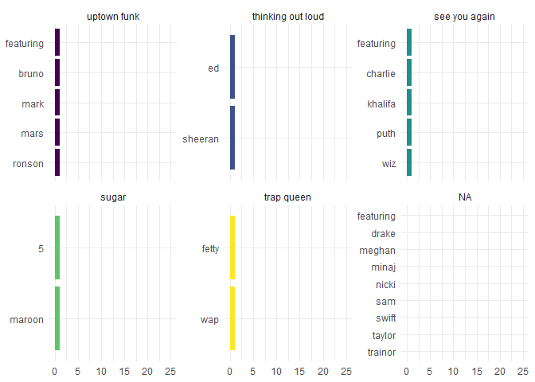

```r
hp_tokens <- top_5 %>%
  unnest_tokens(word, Artist) %>%
  anti_join(stop_words, by = "word") %>% # remove stopwords
  group_by(Song) %>%
  count(word, sort = TRUE) %>%
  top_n(9, n) %>%
  ungroup() %>%
  mutate(word = fct_inorder(word))
# create a bar plot showing the token frequency
ggplot(hp_tokens, aes(x = n, y = fct_rev(word), fill = Song)) +
  geom_col() +
  guides(fill = FALSE) +
  labs(x = NULL, y = NULL) +
  scale_fill_viridis_d() +
  facet_wrap(vars(Song), scales = "free_y") +
  theme_minimal()
```

```r
get_sentiments("loughran")
```

```
## # A tibble: 4,150 × 2
##    word         sentiment
##    <chr>        <chr>
##  1 abandon      negative
##  2 abandoned    negative
##  3 abandoning   negative
##  4 abandonment  negative
##  5 abandonments negative
##  6 abandons     negative
##  7 abdicated    negative
##  8 abdicates    negative
##  9 abdicating   negative
## 10 abdication   negative
## # … with 4,140 more rows
```

```r
complete_records <- na.omit(bill_100)
```